# GCDS: Example

Load libraries. Note how loading matters and can lead to masking functions.

```r
# load some libraries
library(tidyverse)
library(gtsummary)
library(magrittr)
library(performance)
library(modelbased)
library(see)
library(readr)
```

Read some data?

Because there are so many variables in this data set, it serves as a good example to explore and plot from.

```r
DAT <- read_csv(paste0(data_dir, "psa001_agg.csv")) # face data

DAT2 <- read_csv(paste0(data_dir, "pets.csv"))   # pet data also at DSRR
```

View it in html?

```r
# uses the function defined at the top of the file
view(DAT, show = 10)
```

| region | stim_id | aggressive | attractive | caring | confident | dominant | emostable | intelligent | mean | responsible | sociable | trustworthy | unhappy | weird |
| --- | --- | --- | --- | --- | --- | --- | --- | --- | --- | --- | --- | --- | --- | --- |
| Africa | AF-203 | 4.16666666666667 | 5.01315789473684 | 4.9280303030303 | 5.53225806451613 | 5.07894736842105 | 5.23684210526316 | 5.82432432432432 | 4.00980392156863 | 6.625 | 5.30882352941176 | 5.68367346938776 | 4.7906976744186 | 4.27027027027027 |
| Africa | AF-204 | 4.6 | 3.89473684210526 | 5.27272727272727 | 4.58064516129032 | 4.73684210526316 | 4.21052631578947 | 5.39189189189189 | 4.66993464052288 | 5.40277777777778 | 4.89705882352941 | 4.96938775510204 | 5.33720930232558 | 4.75675675675676 |
| Africa | AF-205 | 5.07777777777778 | 4.73684210526316 | 4.65151515151515 | 5.75806451612903 | 5.35526315789474 | 5.21052631578947 | 5.77027027027027 | 4.94117647058824 | 6.16666666666667 | 5.19117647058824 | 4.90816326530612 | 4.96511627906977 | 4.12162162162162 |
| Africa | AF-209 | 4.26666666666667 | 4.96052631578947 | 5.36742424242424 | 5.08064516129032 | 4.97368421052632 | 5.73684210526316 | 5.74324324324324 | 3.84313725490196 | 5.77777777777778 | 5.91176470588235 | 5.69387755102041 | 4.16279069767442 | 3.72972972972973 |
| Africa | AF-211 | 4.22222222222222 | 4.05263157894737 | 4.87878787878788 | 4.46774193548387 | 4.68421052631579 | 4.82894736842105 | 5.66216216216216 | 4.34313725490196 | 5.38888888888889 | 5.29411764705882 | 5.19387755102041 | 5.37209302325581 | 4.06756756756757 |
| Africa | AF-212 | 4.35555555555556 | 3.77631578947368 | 4.55681818181818 | 4.45161290322581 | 4.23684210526316 | 4.56578947368421 | 4.56756756756757 | 4.35294117647059 | 4.875 | 4.36764705882353 | 4.5 | 4.56589147286822 | 6.13513513513514 |
| Africa | AF-222 | 4.34444444444444 | 4.18421052631579 | 4.59848484848485 | 5.33870967741935 | 4.56578947368421 | 5.14473684210526 | 5.48648648648649 | 4.50980392156863 | 5.29166666666667 | 5.60294117647059 | 5.63265306122449 | 5.27131782945736 | 4.94594594594595 |
| Africa | AF-224 | 4.56666666666667 | 4.82894736842105 | 5.06818181818182 | 5.67741935483871 | 4.88157894736842 | 5.14473684210526 | 5.7027027027027 | 4.42156862745098 | 5.51388888888889 | 5.23529411764706 | 5.25510204081633 | 4.87209302325581 | 4.09459459459459 |
| Africa | AF-228 | 4.32222222222222 | 5.14473684210526 | 4.60606060606061 | 5.75806451612903 | 5.22368421052632 | 5.67105263157895 | 5.75675675675676 | 4.58823529411765 | 6.04166666666667 | 4.97058823529412 | 5.44897959183673 | 4.84883720930233 | 4.04054054054054 |
| Africa | AF-229 | 4.27777777777778 | 5.26315789473684 | 5.01515151515152 | 5.87096774193548 | 4.96052631578947 | 5.23684210526316 | 5.90540540540541 | 4.5 | 5.25 | 5.72058823529412 | 5.38775510204082 | 4.88372093023256 | 3.72972972972973 |

[output cut: 1310 more lines]

Working with a data base of faces rated on various dimensions. Need to create new variables based on existing ones?

```r
DAT <- DAT %>%
  # create new variables based on characters
  mutate(sex  = ifelse(grepl("F", stim_id), "Female", "Male"), # using ifelse()
         race = case_when(grepl("B", stim_id) ~ "Black",       # easier using dplyr::case_when()
                          grepl("A", stim_id) ~ "Asian",
                          grepl("W", stim_id) ~ "White",
                          grepl("L", stim_id) ~ "Latino"
                          )
  ) %>%
  # dplyr::select(stim_id, attractive, caring, intelligent, mean, unhappy) %>%
  select(-stim_id) %>%                                # remove 1 ,  - means subtract out
  select(-c(responsible, sociable, weird, emostable)) # remove multiple, -c()
```

Pet data? Barplots?

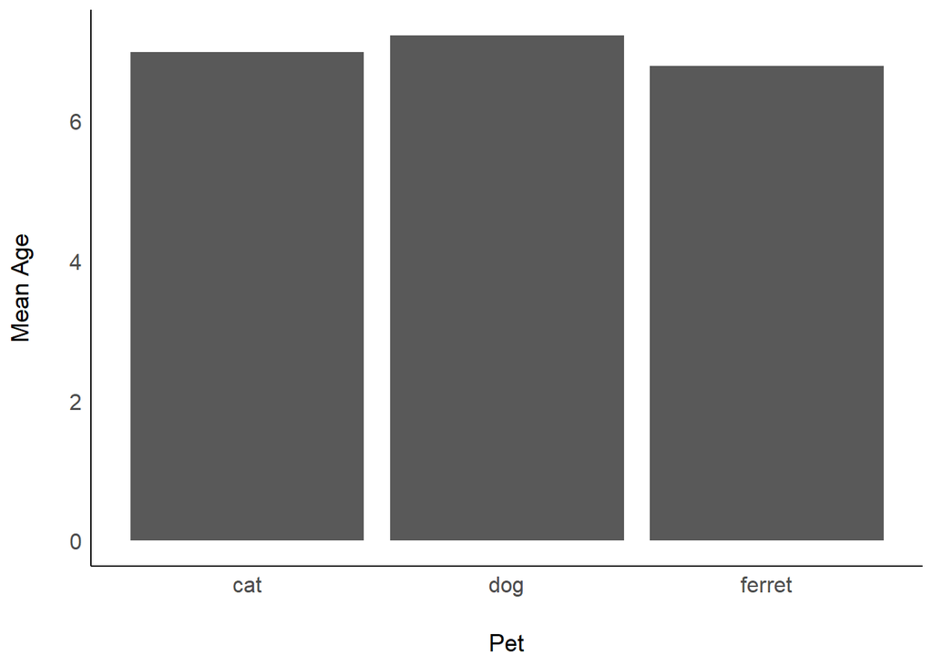

```r
p1 <- DAT2 %>%
  group_by(pet) %>%
  summarise(
    age = mean(age, na.rm = T),
    weight = mean(weight, na.rm = T),
  ) %>%
  ggplot(aes(x = pet, y = age), fill = pet) +
  geom_col() +
  labs(x = "Pet", y = "Mean Age") +
  see::theme_modern()
p1
```

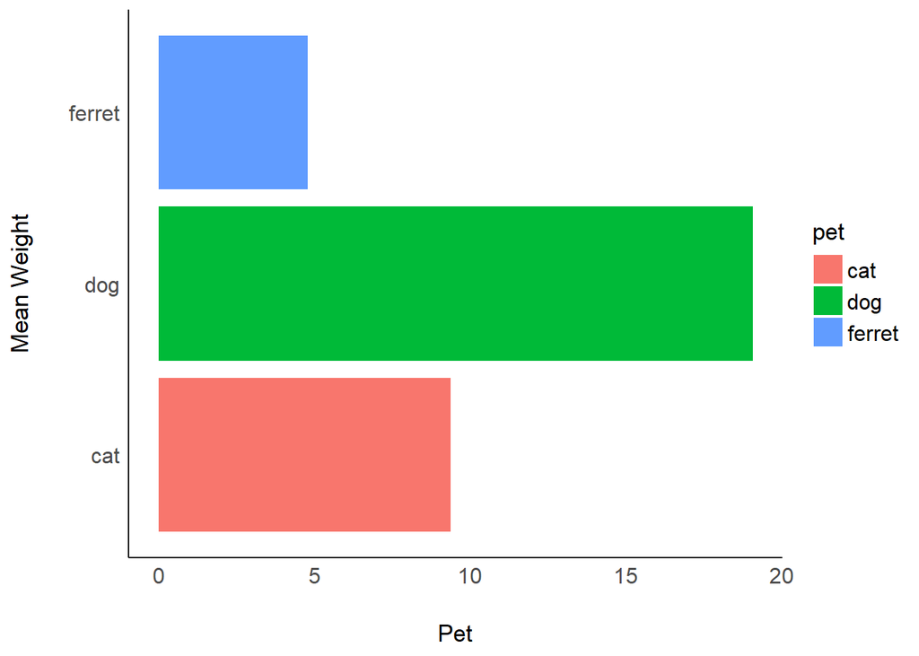

```r
p1 <- DAT2 %>%
  ggplot(., aes(x = weight,
                y = pet,
                fill = pet)) +
  geom_bar(stat = "summary", fun = "mean") + # or stat_summary(fun = "mean", geom = "bar") +
  labs(x = "Pet", y = "Mean Weight") +
  see::theme_modern()
p1
```

Flip the coordinates and change fill color?

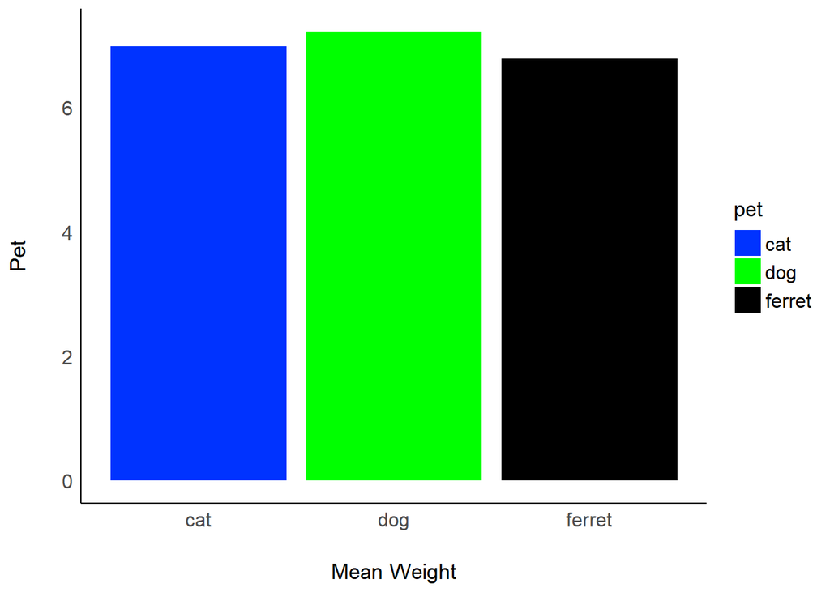

```r
p2 <- p1 +
  aes(x = age) +                                                 # change the aestheics
  scale_fill_manual(values = c("#0033FF", "green", "black")) +   # choose colors
  labs(x = "Pet", y = "Mean Weight") +
  coord_flip()
p2
```

Overlay a boxplot; flag outlier as red triangle? Plot with previous? Though this looks **ugly**.

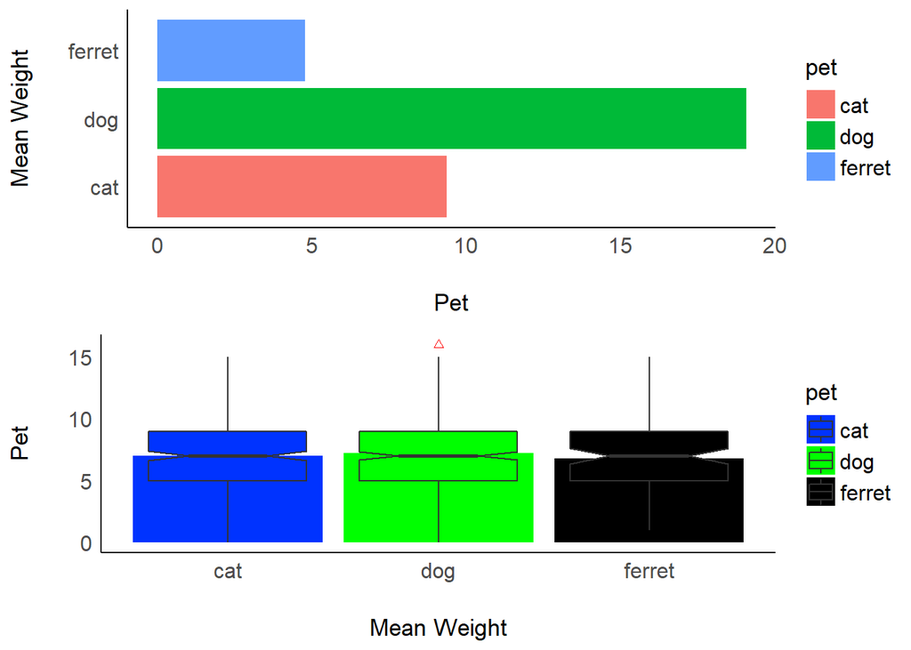

```r
p2 <- p2 + geom_boxplot(notch = T,
                  outlier.shape = 2,
                  outlier.color = "red")

gridExtra::grid.arrange(p1, p2)
```

Scatter plot and marginal box plots?

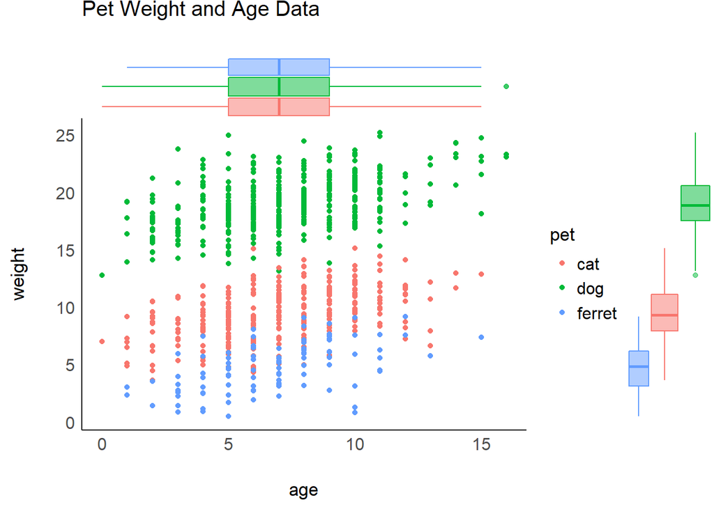

```r
p3 <- DAT2 %>% ggplot(aes(
  x = age,
  y = weight)) +
  geom_point(aes(colour = pet)) +
  see::theme_modern() + ggtitle("Pet Weight and Age Data")

ggExtra::ggMarginal(
  p3,
  type = 'boxplot',
  margins = 'both',
  size = 5,
  groupColour = TRUE,
  groupFill = TRUE
  )
```

A correlation matrix for face ratings?

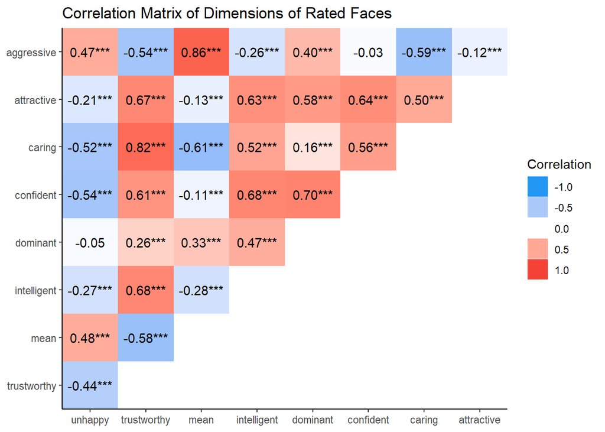

```r
DAT_corr <- correlation::correlation(DAT)

DAT_corr %>%
  summary(redundant = F) %>%
  plot() +           # make the plot
  theme_classic() +  # general classic theme from ggplot2
  ggtitle("Correlation Matrix of Dimensions of Rated Faces") # add your own title
```

Another matrix, with a different theme?

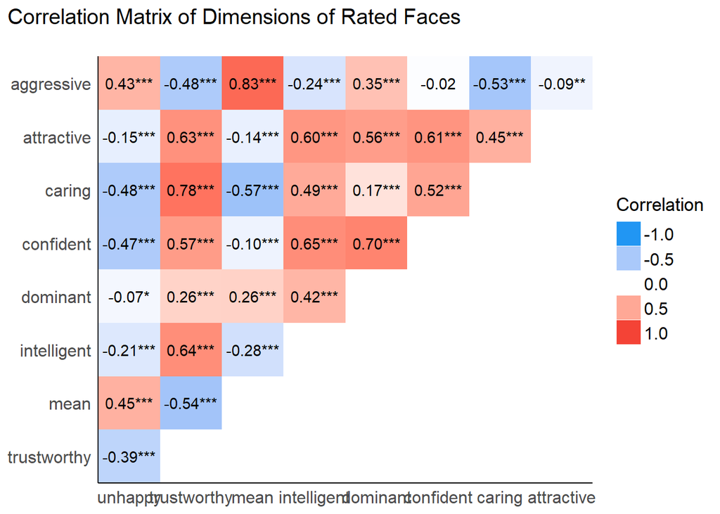

```r
DAT %>%
  correlation::correlation(.,
                           method = "pearson",
                           winsorize = T
                           ) %>%
  summary(., redundant = F) %>%
  plot() +            # plot
  ggtitle("Correlation Matrix of Dimensions of Rated Faces") +    # add your own title
  see::theme_modern() # clean up the plot and put in a modern theme
```

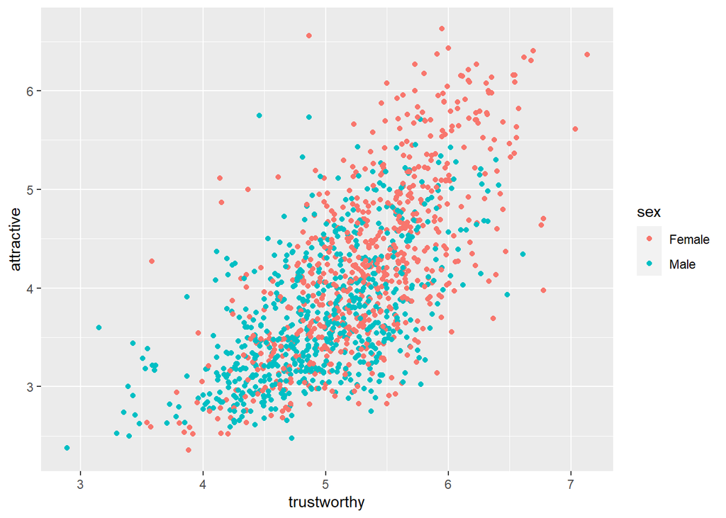

```r
DAT %>% ggplot(aes(
  x = trustworthy,
  y = attractive)) +
  geom_point(aes(colour = sex))
```

Flip the coordinates?

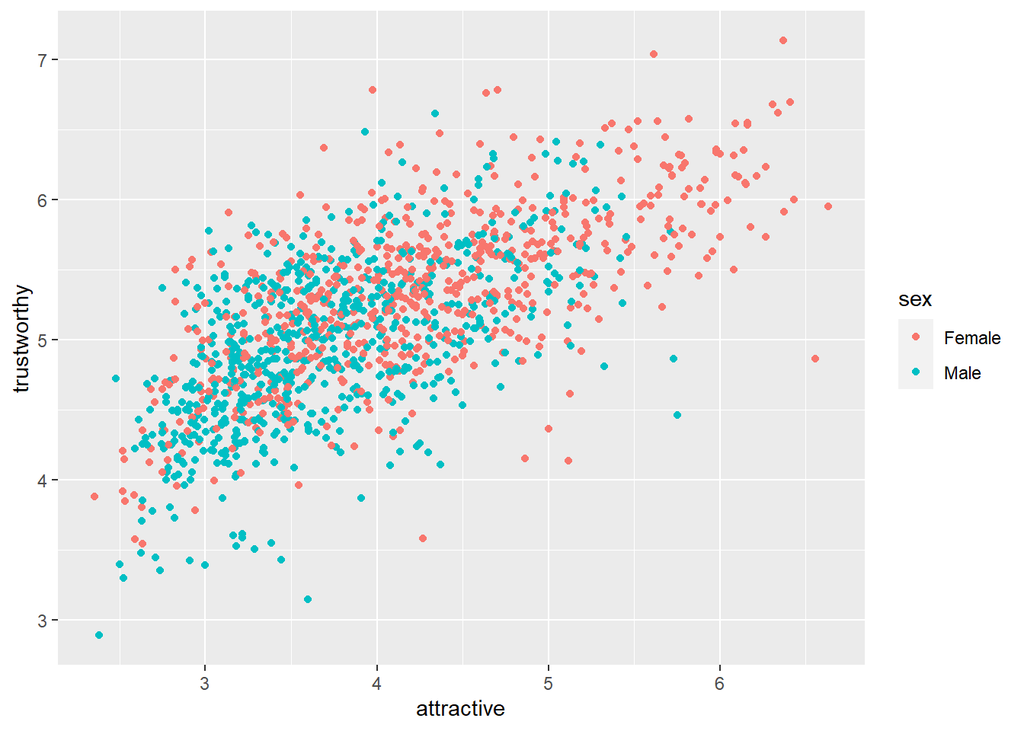

```r
DAT %>% ggplot(aes(
  x = trustworthy,
  y = attractive)) +
  geom_point(aes(colour = sex)) +
  coord_flip()
```

Separate scatter plots with a regression line for each race?

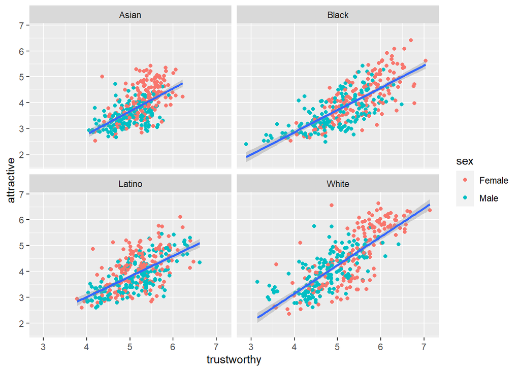

```r
DAT %>% ggplot(aes(
  x = trustworthy,
  y = attractive)) +
  geom_point(aes(colour = sex)) +
  geom_smooth(method = "lm") +
  facet_wrap("race")
```

Separate scatter plots with a loess line for each race?

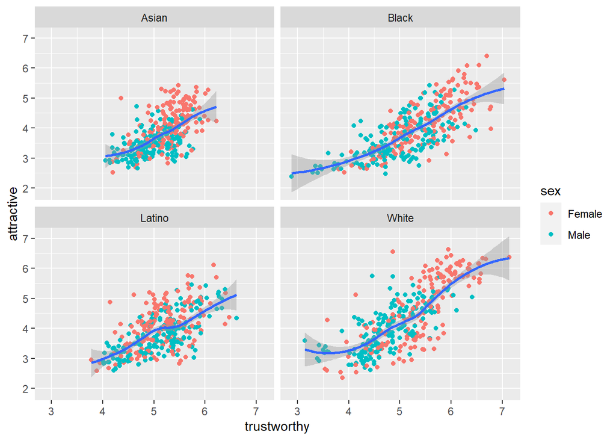

```r
DAT %>% ggplot(aes(
  x = trustworthy,
  y = attractive)) +
  geom_point(aes(colour = sex)) +
  geom_smooth(method = "loess") +
  facet_wrap("race")
```

A linear model?

```r
DAT %>%
  lm(trustworthy ~ attractive, data = .) %>%
  summary() %>%
  broom::tidy() #%>%
```

```
## # A tibble: 2 × 5
##   term        estimate std.error statistic   p.value
##   <chr>          <dbl>     <dbl>     <dbl>     <dbl>
## 1 (Intercept)    3.17     0.0614      51.6 1.52e-318
## 2 attractive     0.497    0.0151      33.0 1.98e-174
```

```r
  #htmlTable::htmlTableWidget()
```

A linear model in a different way?

```r
DAT %>%
  lm(trustworthy ~ attractive, .) %>%
  gtsummary::tbl_regression()
```

| **Characteristic** | **Beta** | **95% CI**<sup>1</sup> | **p-value** |
| --- | --- | --- | --- |
| attractive | 0.50 | 0.47, 0.53 | <0.001 |

<sup>1</sup> CI = Confidence Interval

A simple regression model with assumption checks?

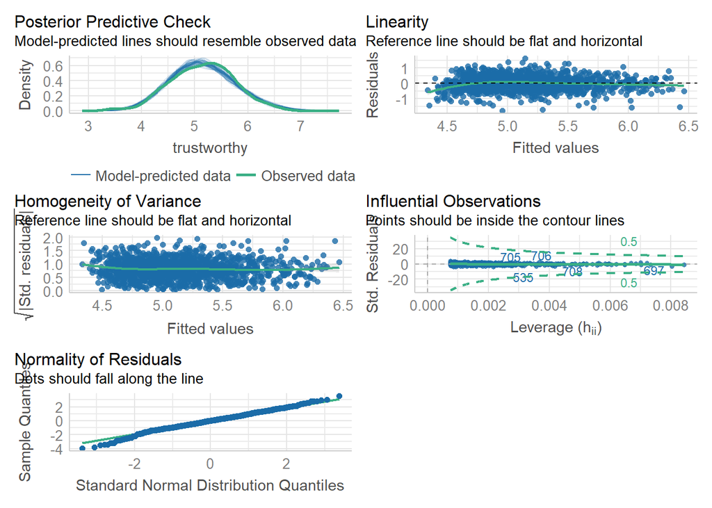

```r
DAT %>%
  lm(trustworthy ~ attractive, data = .) %>% # defining a model
  check_model() # checking model assumptions
```

A multiple regression model?

```r
DAT %>%
  lm(trustworthy ~ attractive + caring, .) %>%
  gtsummary::tbl_regression()
```

| **Characteristic** | **Beta** | **95% CI**<sup>1</sup> | **p-value** |
| --- | --- | --- | --- |
| attractive | 0.26 | 0.24, 0.28 | <0.001 |
| caring | 0.62 | 0.59, 0.65 | <0.001 |

<sup>1</sup> CI = Confidence Interval

A multiple regression model with assumption checks?

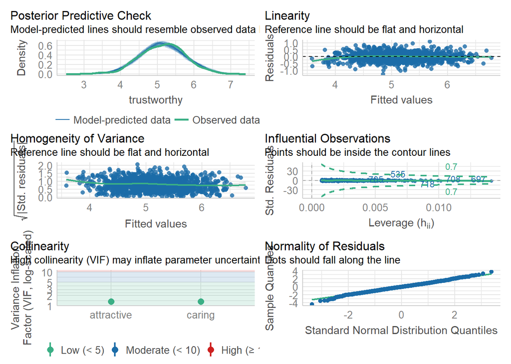

```r
DAT %>%
  lm(trustworthy ~ attractive + caring, data = .) %>%
  check_model() # checking model assumptions
```

A gaussian graphical model?

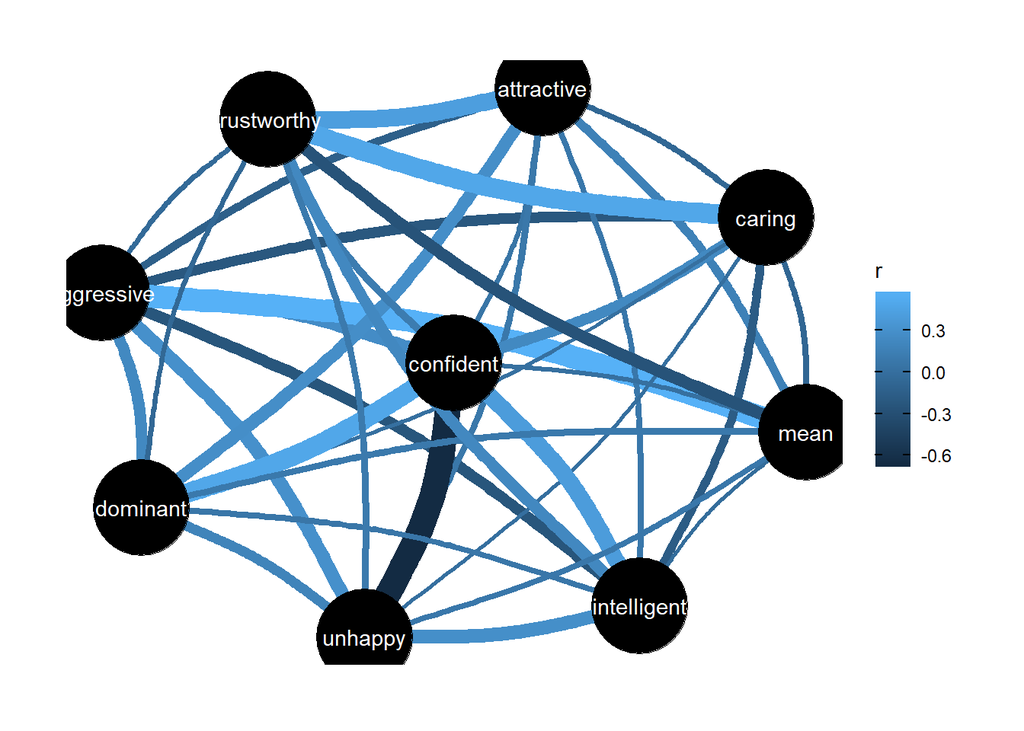

```r
library(ggraph)

DAT %>%
  correlation::correlation(partial = TRUE) %>%
  plot()
```

How about a summary table?

```r
DAT %>%
  # remove from summary table
  dplyr::select(-region) %>%
  tbl_summary(by = race)
```

| **Characteristic** | **Asian**, N = 330<sup>1</sup> | **Black**, N = 330<sup>1</sup> | **Latino**, N = 330<sup>1</sup> | **White**, N = 330<sup>1</sup> |
| --- | --- | --- | --- | --- |
| aggressive | 3.78 (3.38, 4.21) | 4.01 (3.52, 4.46) | 4.03 (3.55, 4.50) | 4.26 (3.68, 4.74) |
| attractive | 3.70 (3.31, 4.22) | 3.87 (3.25, 4.49) | 3.87 (3.36, 4.40) | 4.21 (3.48, 5.10) |
| caring | 4.61 (4.32, 4.94) | 4.94 (4.49, 5.40) | 4.70 (4.26, 5.12) | 4.51 (4.09, 5.07) |
| confident | 5.03 (4.54, 5.40) | 5.42 (4.68, 5.90) | 4.87 (4.47, 5.30) | 5.28 (4.67, 5.86) |
| dominant | 4.41 (4.00, 4.74) | 4.87 (4.32, 5.33) | 4.46 (4.08, 5.00) | 4.87 (4.37, 5.29) |
| intelligent | 5.66 (5.28, 5.97) | 5.30 (4.78, 5.83) | 5.34 (4.84, 5.67) | 5.43 (5.00, 5.85) |
| mean | 3.90 (3.49, 4.26) | 3.82 (3.39, 4.31) | 4.08 (3.55, 4.50) | 4.36 (3.76, 4.82) |
| trustworthy | 5.18 (4.85, 5.45) | 5.22 (4.72, 5.71) | 5.16 (4.78, 5.50) | 5.08 (4.53, 5.61) |
| unhappy | 4.39 (4.00, 4.79) | 4.23 (3.68, 4.81) | 4.55 (4.08, 5.00) | 4.44 (3.93, 4.84) |
| sex |  |  |  |  |
| Female | 165 (50%) | 165 (50%) | 165 (50%) | 165 (50%) |
| Male | 165 (50%) | 165 (50%) | 165 (50%) | 165 (50%) |

<sup>1</sup> Median (IQR); n (%)

Choose your own stats?

```r
DAT %>%
  # remove from summary table
  dplyr::select(-region) %>%
  tbl_summary(by = race,
    # custom statistic formats ----
    statistic = list(all_continuous() ~ "{mean} ({sd})",
                     all_categorical() ~ "{p}% ({n} / {N})")
  )
```

| **Characteristic** | **Asian**, N = 330<sup>1</sup> | **Black**, N = 330<sup>1</sup> | **Latino**, N = 330<sup>1</sup> | **White**, N = 330<sup>1</sup> |
| --- | --- | --- | --- | --- |
| aggressive | 3.80 (0.59) | 3.99 (0.67) | 4.05 (0.70) | 4.28 (0.80) |
| attractive | 3.79 (0.63) | 3.91 (0.81) | 3.91 (0.71) | 4.33 (1.02) |
| caring | 4.63 (0.50) | 4.92 (0.71) | 4.70 (0.63) | 4.56 (0.68) |
| confident | 4.98 (0.62) | 5.27 (0.83) | 4.94 (0.69) | 5.25 (0.80) |
| dominant | 4.40 (0.58) | 4.80 (0.70) | 4.54 (0.64) | 4.80 (0.72) |
| intelligent | 5.60 (0.51) | 5.25 (0.68) | 5.27 (0.56) | 5.43 (0.59) |
| mean | 3.91 (0.58) | 3.86 (0.66) | 4.05 (0.66) | 4.37 (0.76) |
| trustworthy | 5.14 (0.42) | 5.23 (0.71) | 5.14 (0.55) | 5.07 (0.72) |
| unhappy | 4.37 (0.61) | 4.29 (0.89) | 4.50 (0.67) | 4.36 (0.68) |
| sex |  |  |  |  |
| Female | 50% (165 / 330) | 50% (165 / 330) | 50% (165 / 330) | 50% (165 / 330) |
| Male | 50% (165 / 330) | 50% (165 / 330) | 50% (165 / 330) | 50% (165 / 330) |

<sup>1</sup> Mean (SD); % (n / N)

Add some styling?

```r
DAT %>%
  # remove from summary table
  dplyr::select(-region) %>%
  dplyr::select(-sex) %>%
  tbl_summary(by = race,
    # custom statistic formats ----
    statistic = list(all_continuous() ~ "{mean} ({sd})",
                     all_categorical() ~ "{p}% ({n} / {N})")
  ) %>%
  add_overall() %>%     # add an overall column
  add_n() %>%           # add column with total number of non-missing observations
  add_p() %>%           # test for a difference between groups
  bold_labels()
```

| **Characteristic** | **N** | **Overall**, N = 1,320<sup>1</sup> | **Asian**, N = 330<sup>1</sup> | **Black**, N = 330<sup>1</sup> | **Latino**, N = 330<sup>1</sup> | **White**, N = 330<sup>1</sup> | **p-value**<sup>2</sup> |
| --- | --- | --- | --- | --- | --- | --- | --- |
| aggressive | 1,320 | 4.03 (0.72) | 3.80 (0.59) | 3.99 (0.67) | 4.05 (0.70) | 4.28 (0.80) | <0.001 |
| attractive | 1,320 | 3.98 (0.83) | 3.79 (0.63) | 3.91 (0.81) | 3.91 (0.71) | 4.33 (1.02) | <0.001 |
| caring | 1,320 | 4.70 (0.65) | 4.63 (0.50) | 4.92 (0.71) | 4.70 (0.63) | 4.56 (0.68) | <0.001 |
| confident | 1,320 | 5.11 (0.75) | 4.98 (0.62) | 5.27 (0.83) | 4.94 (0.69) | 5.25 (0.80) | <0.001 |
| dominant | 1,320 | 4.64 (0.68) | 4.40 (0.58) | 4.80 (0.70) | 4.54 (0.64) | 4.80 (0.72) | <0.001 |
| intelligent | 1,320 | 5.39 (0.60) | 5.60 (0.51) | 5.25 (0.68) | 5.27 (0.56) | 5.43 (0.59) | <0.001 |
| mean | 1,320 | 4.05 (0.70) | 3.91 (0.58) | 3.86 (0.66) | 4.05 (0.66) | 4.37 (0.76) | <0.001 |
| trustworthy | 1,320 | 5.15 (0.61) | 5.14 (0.42) | 5.23 (0.71) | 5.14 (0.55) | 5.07 (0.72) | 0.010 |
| unhappy | 1,320 | 4.38 (0.72) | 4.37 (0.61) | 4.29 (0.89) | 4.50 (0.67) | 4.36 (0.68) | <0.001 |

<sup>1</sup> Mean (SD)  
<sup>2</sup> Kruskal-Wallis rank sum test